# 理解言语信息

林闻正|Lin Wenzheng

## 符号与语言

- 缩写
  - tl；dr
  - yyds
  - awsl/阿伟死了
  - nb
  - orz
  - 社死
  - 默秒全
  - 又能怎
- 语码转换: 在一种语言形式和另一种语言形式之间无缝转换
- 言语的力量

[figure not shown]

## 为什么关注语言？

- 言语是强有力的
  - 它们影响你的情绪、思想、行动和人际关系

[figure not shown]

- 我们主动选择了语言
  - 即使选择发生在一瞬间之中，我们的大脑也是需要选择一个符号（词）来传达我们的想法或冲动

## 语言的本质

- 语言（language）是一个符号系统（单词或词汇），由一个群体共同的语法（规则和标准）和句法（单词的排列模式）所构成
- 萨丕尔-沃尔夫假说：人类的语言和思维相互关联之紧密，以至于思维实际上源于语言并受其控制

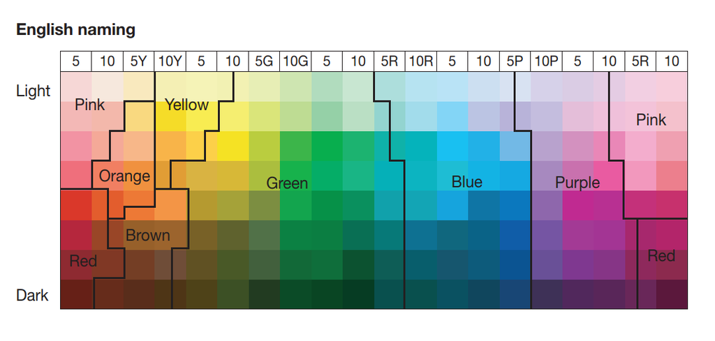

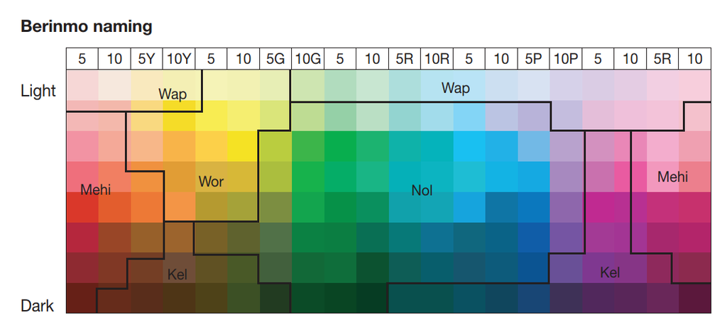

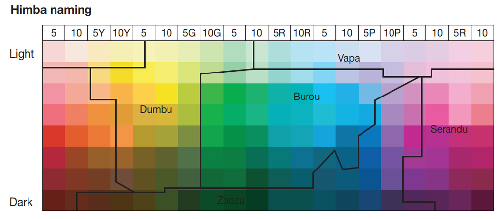

  - 相较于你的母语，一些思想、情感或冲动可能用其他的语言来表达会更好
  - 学习其他的语言，你的思维也能得到扩展

## 语言的本质（2）

- 人们像使用符号一样使用词语
- 人们赋予词语意义
  - 意义：某人对某个符号的解读
  - 各说自话：当同样的词对不同的人所意味的事情不同时出现的沟通问题
- 人们为词语创造了外延意义和内涵意义
  - 外延意义（denotative meaning）：某个词语其限制性的或字面上的意义
  - 内涵意义（connotative meaning）：某个词语其个人的且主观的意义
- 人们通过词语表达具体意义和抽象意义
  - 具体意义（concrete meaning）：其所指代之物能够被感官感知到的词语意义
  - 抽象意义（abstract meaning）：其所指代之物不能被感官感知或经验到的词语意义

## 语言的本质（3）

- 意义受到文化的约束
  - 文化（Culture）是一个知识、行为、态度、信仰、价值观、规则和规范的习得性系统，由群体所共享且形成于代代相传之中
  - 共文化（co-culture）：存在于一个更大的文化内部的小规模文化群体
    - “窝心”
  - 新语（neologism）：新引入语言的用语
    - 她
- 意义受到语境的约束

## 言语的力量（1）

[figure not shown]

- 言语能够伤人
- 言语也能够治愈、激励和改变人们的精神

## 言语的力量（2）

- 创造和标记经验的力量
- 沟通情感的力量
- 影响思维和行为的力量
- 塑造和反映文化的力量